# PTUT – Analyse des données concernant la fabrication des Fourmes d’Ambert

18 Juin 2025

VEYRAC Maëlys & GODEFROY Tanguy

## Introduction

Dans le cadre de notre projet tutoré, nous devions réaliser un analyse descriptive de données que nous avons mises en forme concernant la fabrication des Fourmes d’Ambert. La Fourme d’Ambert est un fromage AOP originaire d’Auvergne. Il s’agit d’un fromage au lait de vache, à pâte persillée avec une forme cylindrique. Les données proviennent de trois transformateurs différents. Afin d’anonymiser les données, les trois transformateurs seront appelés `T1`, `T2` et `T3`. Ces données sont relatives à toutes les étapes de la fabrication de ce fromage : prématuration, maturation, emprésurage, brassage, moulage, salage, piquage, affinage… Nous avons au total 44 variables, concernant le pH, la température du lait, les durées de chaque étapes de fabrications, etc. Nous allons nous concentrer sur certaines variables lors de notre analyse, en voici la liste :

- $\Rightarrow$ Le pH lors de l’emprésurage
- $\Rightarrow$ Le pH au moment du salage
- $\Rightarrow$ Le temps de coagulation
- $\Rightarrow$ Le nombre de fromages produits

Au cours de notre analyse, nous utiliserons des méthodes de statistique descriptive univariée telles que la moyenne et l’écart-type ainsi que des méthodes de statistique descriptive bivariée telles que la régression linéaire. Ainsi, nous allons pour chacune des variables essayer de trouver des liens avec d’autres variables grâce à des modèles de régression et des paramètres statistiques. L’objectif de cette analyse est de permettre aux fabricants de Fourmes d’Ambert de suivre la qualité des fromages et d’améliorer leur chaîne de production.

Concernant le déroulé de notre analyse, nous étudierons dans un premier temps l’évolution du pH au cours de la fabrication de la Fourme d’Ambert en précisant les variables suceptibles d’avoir une influence sur ce dernier. Dans un second temps, nous analyserons le temps de coagulation et les variables ayant un impact sur ce dernier. Enfin, nous analyserons le nombre de fromages produits par lot.

## Analyse

### L’évolution du pH au cours de la fabrication de la Fourme d’Ambert

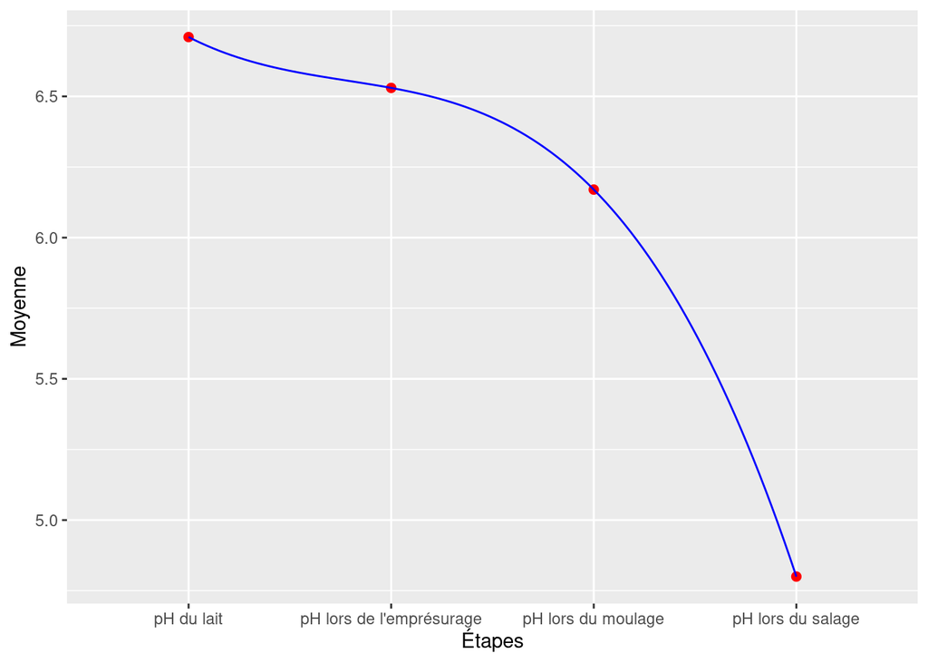

On observe que le pH diminue, celui-ci s’acidifie donc au cours de sa fabrication. En conséquence, nous allons tenter de repérer les variables qui impactent le pH du fromage et ainsi entraînent l’acidification de celui-ci. Nous nous concentrerons plus particulièrement sur le pH lors de l’emprésurage et lors du salage.

#### Le pH lors de l’emprésurage

Voici un tableau résumant quelques paramètres pour chaque transformateur :

| transformateur | Moyenne | Minimum | Maximum | Ecart-type |
| --- | --- | --- | --- | --- |
| T1 | 6.47 | 6.44 | 6.49 | 0.019 |
| T2 | 6.58 | 6.49 | 6.63 | 0.052 |
| T3 | 6.58 | 6.55 | 6.63 | 0.032 |
| Total | 6.53 | 6.44 | 6.63 | 0.068 |

##### `pH du lait` en fonction du `pH à l'emprésurage`

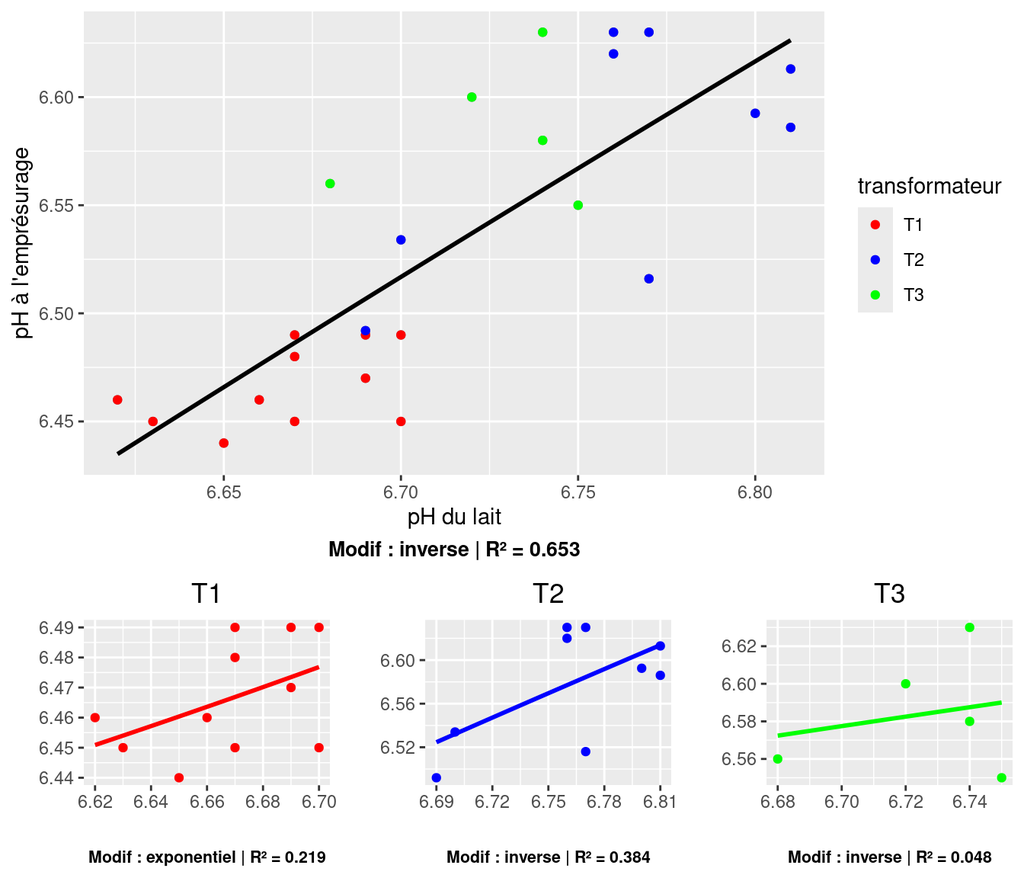

Le pH lors de la phase d’emprésurage paraît conditionné par le ph mesuré au départ, lorsque le lait est dans la cuve. Cela paraît logique de premier abord, il y a un lien entre les deux pH.

##### `pH à l'emprésurage` en fonction de la `levure`

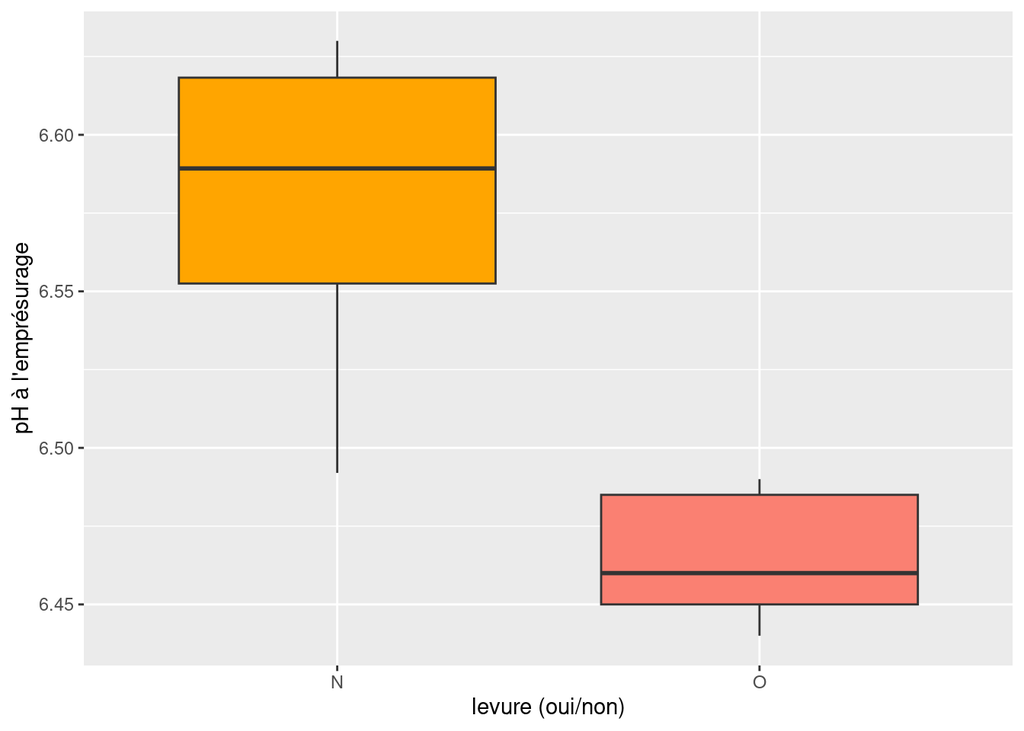

*PS : Si la levure n’est pas insérée au moment de la prématuration, alors elle est insérée au moment de la maturation*

##### `pH à l'emprésurage` en fonction du `transformateur`

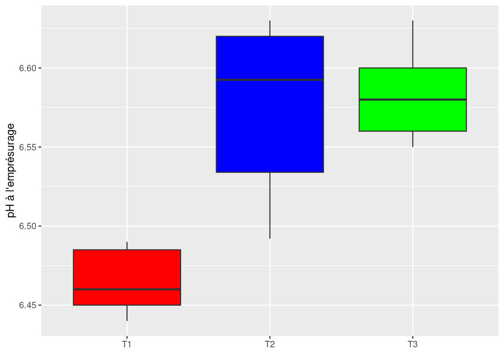

On voit ici que le transformateur `T1` obtient des pH d’emprésurage bien plus faibles par rapport aux deux autres. On peut supposer que les conditions de fabrication du fromage de ce transformateur sont différentes et impactent sur le pH.  
Notons tout de même que le pH du lait est globalement plus faible initialement pour le transformateur `T1` *(voir `pH du lait` en fonction du `pH à l'emprésurage`)*.  
Mais alors le moment d’insertion de la levure est-il le seul facteur influençant le pH du fromage ?

##### `pH à l'emprésurage` en fonction du `type de présure`

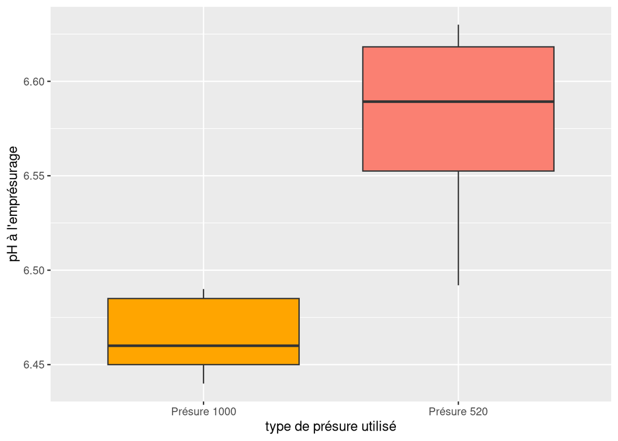

Le type de présure utilisé différencie notamment le transformateur`T1` des deux autres. La *présure 1000* (utilisée par `T1`) pourrait être à l’origine d’un pH plus faible, et la *présure 520* (utilisée par `T2` et `T3`) à l’origine d’un pH plus élevé. Cette observation laisse tout de même à désirer car le pH initial pour le transformateur `T1` est plus faible initialement.

##### `pH à l'emprésurage` en fonction de la `température d'emprésurage`

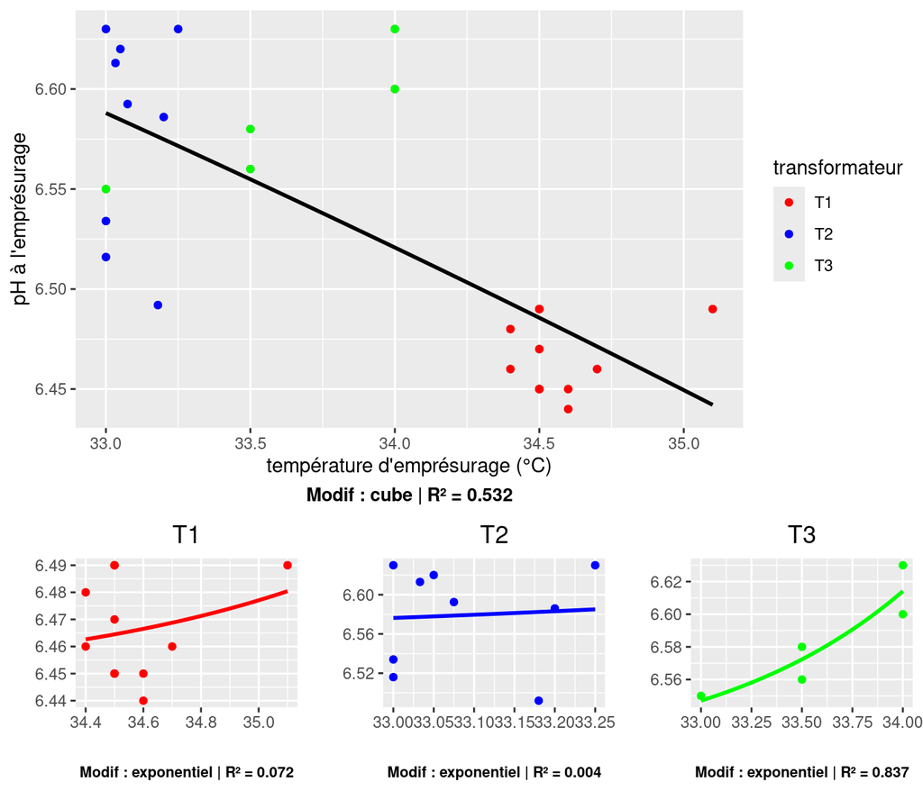

Globalement, lors de l’emprésurage, le pH diminue lorsque la température augmente. Cependant, pour le transformateur `T3`, une tendance inverse semble apparaître, ce qui nous laisse tout de même perplexe… Regardons le lien avec une dernière variable avant de passer au pH lors du salage, le `temps de prise`.

##### `pH à l'emprésurage` en fonction du `temps de prise`

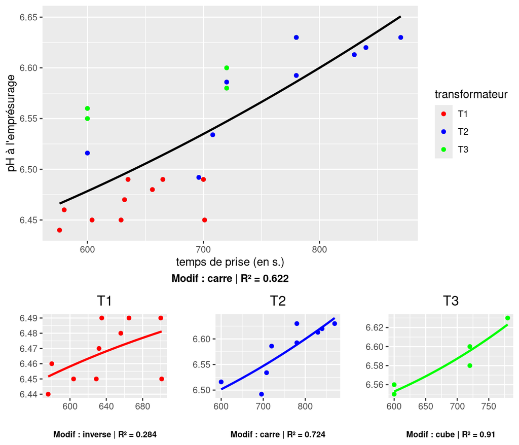

Le pH lors de l’emprésurage augmente lorsque le temps de prise augmente. On observe une corrélation entre les deux variables assez forte et en accord pour tous les transformateurs. Il semble donc que ce paramètre soit très influent dans la variation du pH lors de la fabrication du fromage.

On peut en conclure que le `pH à l'emprésurage` est influencé principalement par 3 facteurs : le `pH du lait initial`, le moment d’ajout de la `levure` et enfin le `temps de prise`. Il serait donc intéressant d’analyser l’influence de ces variables sur les autres et aussi sur le ressenti gustatif.

#### Le pH au moment du salage

##### `pH au salage` en fonction du `pH du lait`

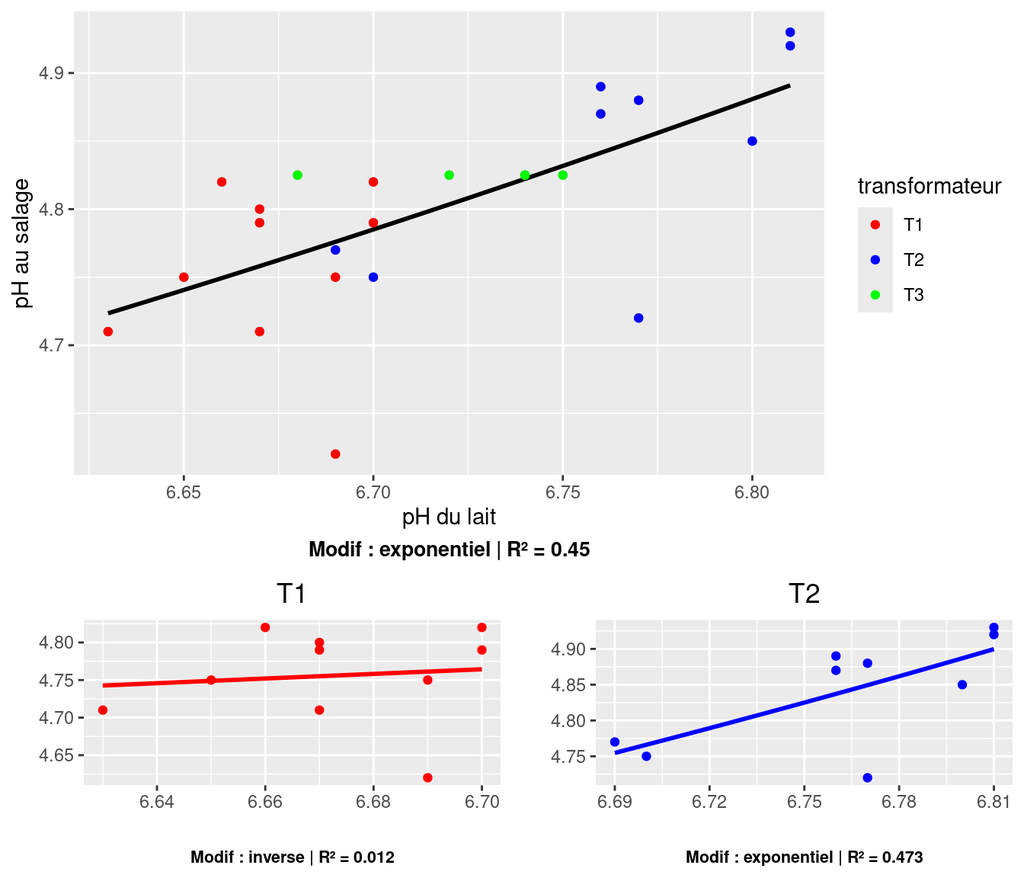

Nous avions précédemment remarqué qu’il y avait une forte liaison entre le pH du lait mesuré dans la cuve et le pH relevé lors de l’emprésurage (coefficient de détermination égal à `0.653`). Ici, on constate que lors du salage (une phase plus avancée dans la fabrication du fromage), il y a toujours une liaison entre le pH mesuré lors de cette phase et le pH de départ. Cependant, cette liaison est moins forte (coefficient de détermination plus faible). D’autres facteurs ont donc influencé ce pH. On remarque aussi que le pH au salage pour le transformateur `T3` est constant par rapport au `pH du lait`, ce transformateur arrive donc à le stabiliser. C’est un atout plutôt intéressant !

##### `pH au salage` en fonction du `salage à sec`

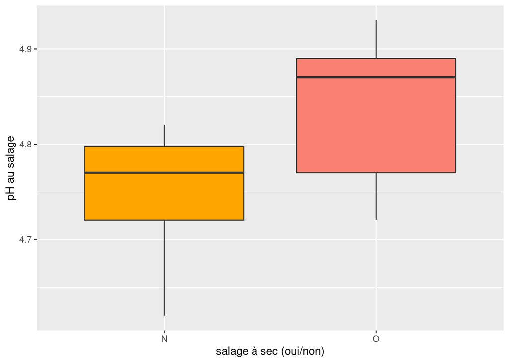

Pour ces 2 boxplots nous avons retiré le transformateur `T3` car celui-ci pratique un salage à sec et un salage saumure, ce qui fausserai notre analyse.

Lors du salage, le pH est un peu plus élevé quand le salage à sec est pratiqué. Avec un salage en saumure, la diminution du pH est plus importante. Notons que les boxplots se chevauchent, la différence n’est donc pas très significative.

*PS : Si le salage n’est pas à sec alors il est en saumure pour les transformateurs `T1` et `T2`*

##### `pH au salage` en fonction du `nombre de retournements`

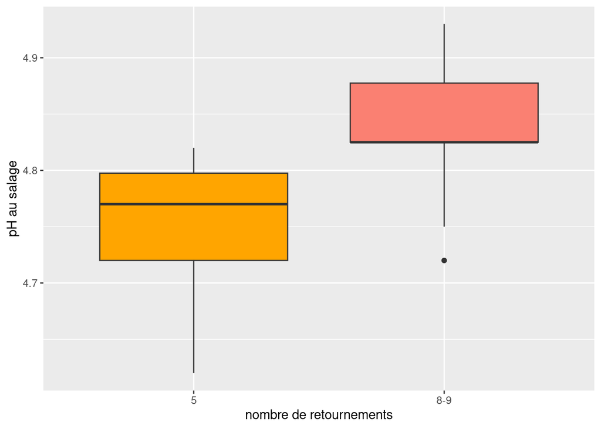

Il semble que le nombre de retournements des fromages a une influence sur le pH mesuré lors du salage. Pour un nombre de retournements plutôt faible (5 retournements), le pH est plus faible que lorsque 8 à 9 retournements sont réalisés.

##### `pH au salage` en fonction de la `durée d'égouttage`

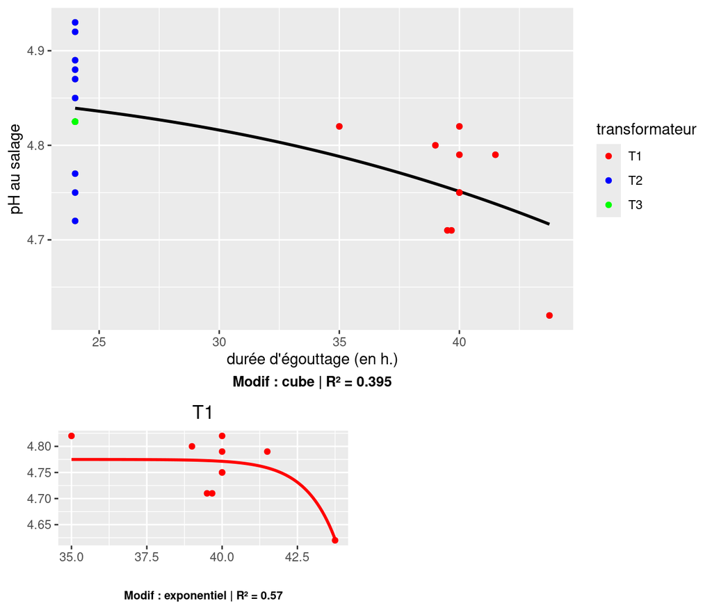

Il semble que le pH lors du salage est légèrement plus élevé lorsque la durée d’égouttage est faible. Plus on laisse égoutter le fromage, plus le pH lors du salage diminue. De plus, pour le transformateur T1, on observe que le pH reste à peu près constant tant que la durée de l’égoutage est inférieure à 41 heures. Lorsque cette durée dépasse 41 heures, le pH chute brutalement.

En conclusion le `nombre de retournement` est le facteur le plus influent dans l’évolution du `pH au salage`. Il serait intéressant de trouver comment le transformateur `T3` arrive à stabiliser ses pH au moment du salage.

### Le temps de coagulation

Voici un tableau résumant quelques paramètres pour chaque transformateur (en minutes) :

| transformateur | Moyenne | Minimum | Maximum | Ecart-type |
| --- | --- | --- | --- | --- |
| T1 | 46 | 45 | 55 | 3 |
| T2 | 57 | 44 | 67 | 7 |
| T3 | 27 | 25 | 31 | 2 |
| Total | 46 | 25 | 67 | 11 |

On remarque que le transformateur `T2` obtient des valeurs beaucoup plus variables que les autres, est-ce dû à des erreurs de mesures ? Ou à des procédés différents ? C’est une bonne question à laquelle nous n’avons pas la réponse malheureusement…

##### `temps de coagulation` en fonction du `temps de prise`

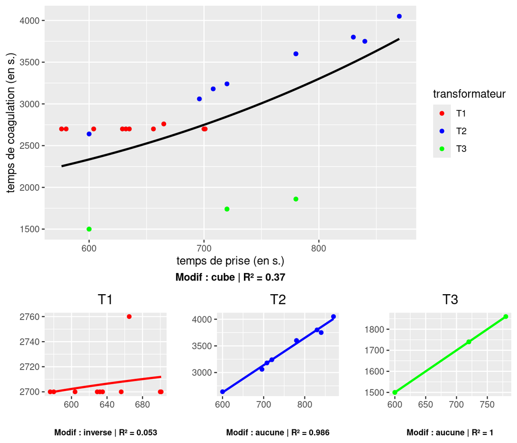

On observe une corrélation entre le temps de coagulation et le temps de prise ; lorsque le temps de prise augmente, le temps de coagulation augmente également. Le temps de prise influe donc beaucoup sur le temps de coagulation.  
Les modèles pour `T2` et `T3` sont plutôt bien ajustés et permettent de bonnes prédictions.

##### `temps de coagulation` en fonction de la `durée de brassage`

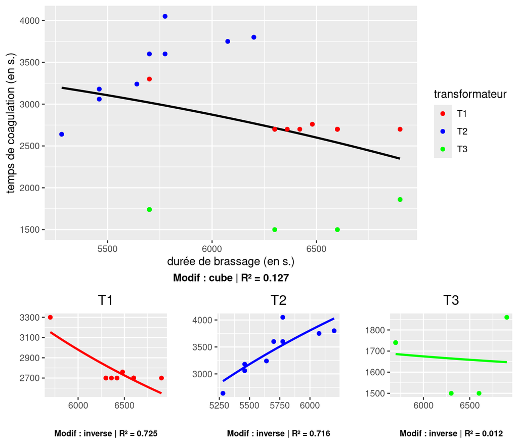

De façon globale, il ne semble pas y avoir de liaison forte entre le temps de coagulation et la durée de brassage. Cependant, pour les transformateurs `T1` et `T2`, on observe une forte corrélation. Étonnamment, les deux transformateurs s’opposent. Pour le transformateur `T1`, plus la durée de brassage est élevée, plus le temps de coagulation est court. Alors que pour le transformateur `T2`, une durée de brassage élevée entraîne un temps de coagulation élevé. Aucune tendance ne se dégage pour la courbe du troisième transformateur. Il est ainsi assez compliqué d’en déduire quelque chose de façon globale, le procédé de fabrication influe entièrement sur ce paramètre.

##### `Temps de coagulation` en fonction du `pH au moulage`

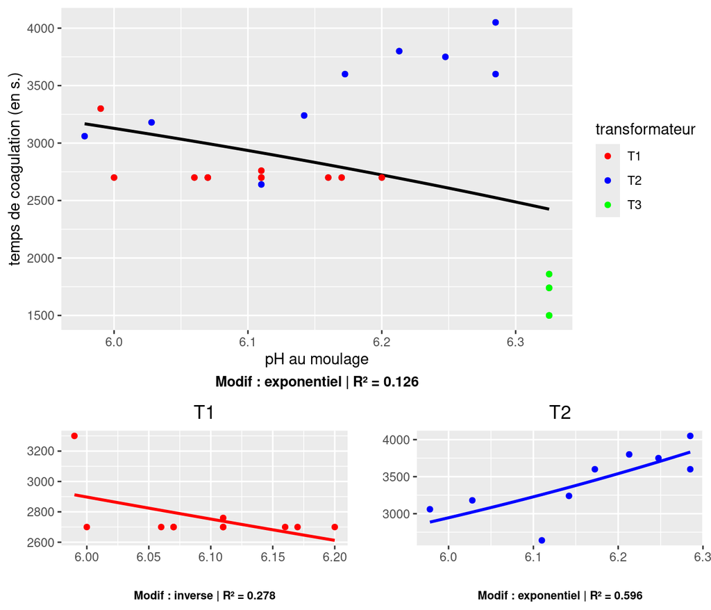

Ici, les transformateurs `T1` et `T2` s’opposent. Lorsque le pH à la phase du moulage est élevé, le temps de coagulation est faible en ce qui concerne le transformateur `T1`. L’effet inverse se produit pour le transformateur `T2`. Cependant, en considérant les trois transformateurs en même temps, aucune liaison ne se dégage.

##### `temps de coagulation` en fonction du `pH à l'emprésurage`

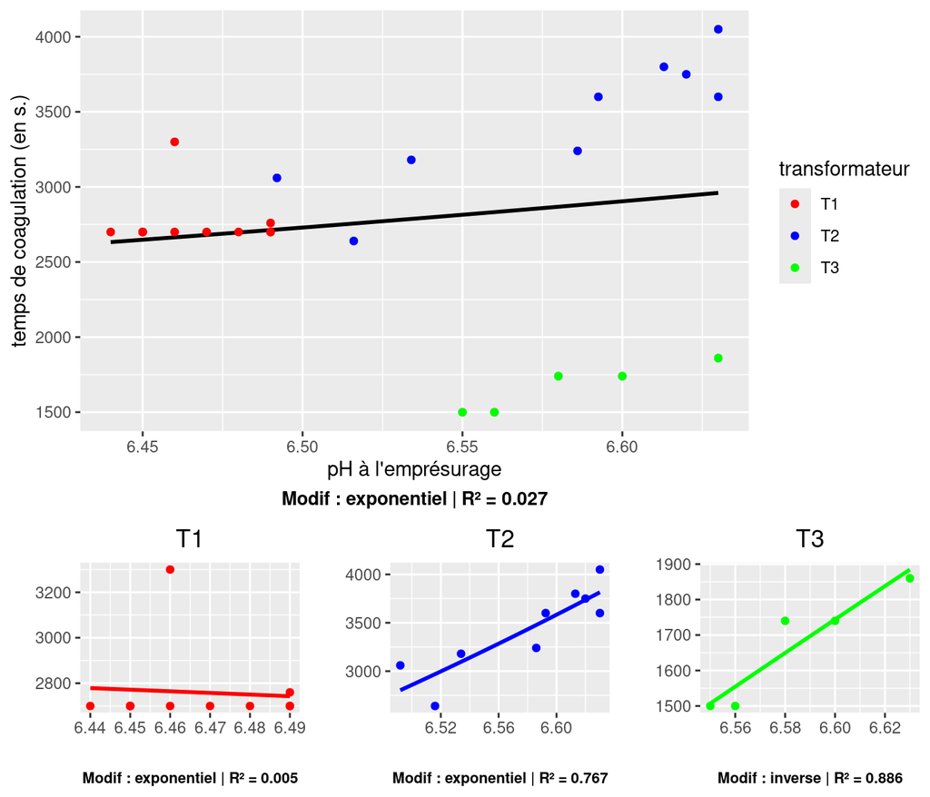

Pour les transformateurs `T2` et `T3`, un pH lors de l’emprésurage élevé entraîne un temps de coagulation plus élevé. Pour ces 2 transformateurs, la droite de régression est plutôt bonne. Pour `T1`, les données sont constantes avec 2 erreurs.

##### `temps de coagulation` en fonction de la `durée d'affinage`

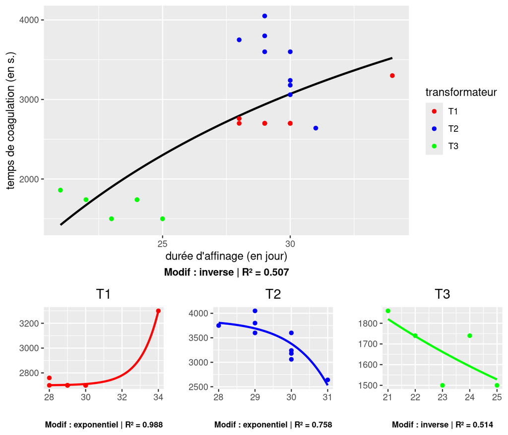

En conclusion, de le temps de coagulation est influencé principalement par le `temps de prise`, le `pH à l'emprésurage` et la `durée d'affinage`. Au vu des modèles obtenus, il est assez compliqué d’examiner l’influence de ces paramètres de façon globale.

### Le nombre de fromages produits

| transformateur | Moyenne | Minimum | Maximum | Ecart-type |
| --- | --- | --- | --- | --- |
| T1 | 343 | 324 | 354 | 8 |
| T2 | 328 | 315 | 345 | 10 |
| T3 | NA | NA | NA | NA |
| Total | 336 | 315 | 354 | 12 |

##### `nombre de fromages` en fonction du `litrage`

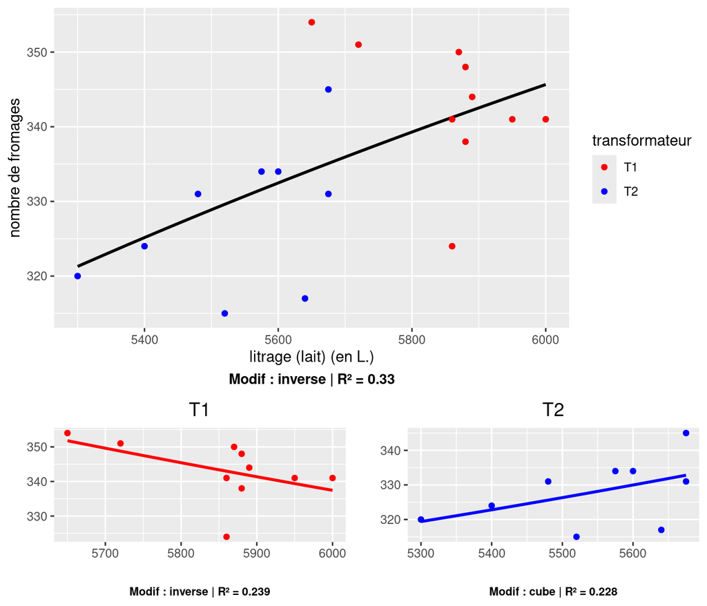

Lorsque le litrage augmente, le nombre de fromages produits augmente également. Cela semble évident. Afin d’étudier le rendement du nombre de fromages, nous avons crée une nouvelle colonne : `Ratio nombre de fromage / litrage` qui est égale au nombre de fromages divisé par le litrage.

| transformateur | Moyenne | Minimum | Maximum | Ecart-type |
| --- | --- | --- | --- | --- |
| T1 | 5.86 % | 5.53 % | 6.27 % | 0.22 % |
| T2 | 5.92 % | 5.62 % | 6.08 % | 0.16 % |
| T3 | NaN % | Inf % | -Inf % | NA % |
| Total | 5.89 % | 5.53 % | 6.27 % | 0.19 % |

En moyenne, le rendement est de `5.89 %` de fromage pour un litre. Pour fabriquer un fromage, il faut donc environ `17 L` de lait.

##### `quantité de fromage produit` en fonction du `transformateur`

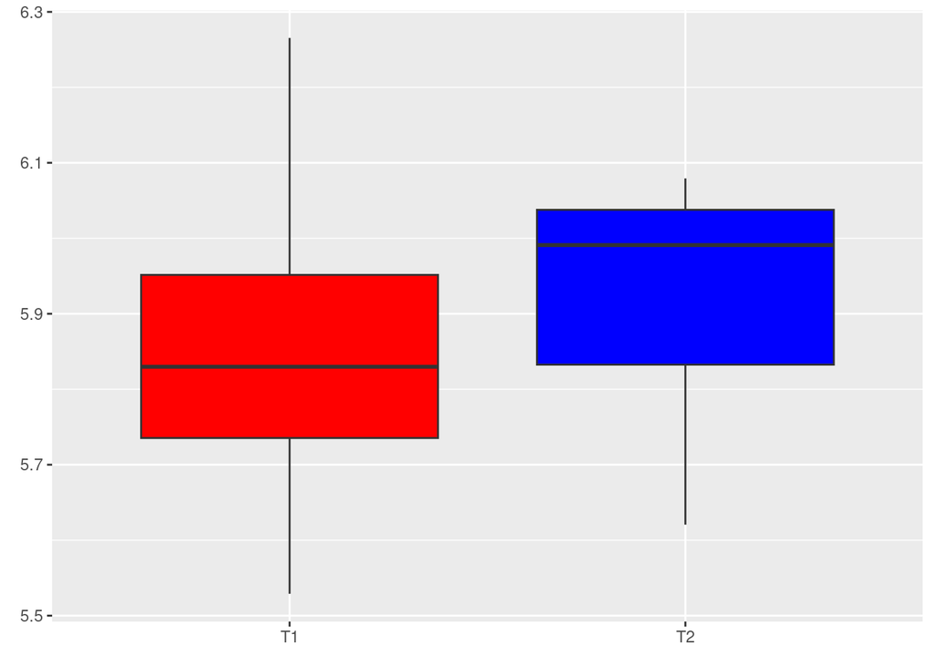

Le transformateur `T2` a une méthode de fabrication du fromage qui lui permet d’avoir un meilleur rendement. Avec un même litrage, il est capable de produire plus de fromages. Malheureusement, les données concernant le transformateur `T3` sont absentes.

En conclusion, il serait intéressant de chercher comment `T2` arrive à produire plus de fromages afin d’optimiser le rendement des autres transformateurs.

## Conclusion

En conclusion, on peut observer que certains paramètres en influent d’autres. Par exemple plus le temps de coagulation est élevé plus la durée d’affinage est longue, cela pourrait laisser entendre qu’abaisser le temps de coagulation permettrait de diminuer le temps d’affinage et ainsi gagner du temps sur la fabrication. De plus, il serait intéressant d’analyser plus en détail pourquoi le transformateur T2 arrive à produire plus de fromages pour la même quantité de lait. Toutes ces analyses pourront permettre, après d’autres études plus spécifiques, d’améliorer le procédé de fabrication de la Fourme d’Ambert. Cependant, il faut noter que les données manquantes sur certaines variables clés et la taille limitée de l’échantillon (3 transformateurs) rendent plus difficile l’étude statistique.

## Remerciement

Nous remercions l’équipe de scientifiques ainsi que notre enseignant référent Monsieur GROLLEMUND Paul-Marie pour nous avoir permis de partager ce travail.